# Bayesian Computation with R

Now that we have found the posterior distribution, we use the function simcontour() to simulate pairs of $(\beta_{0},\beta_{1})$ from the posterior density computed on this rectangular grid. We display the contour plot with the points superimposed to confirm that we are sampling from the posterior distribution.

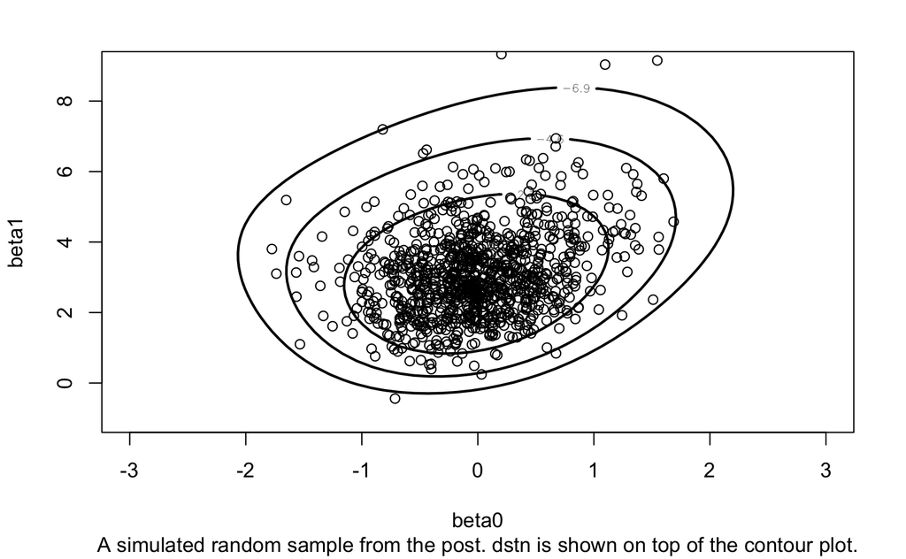

```r
s = simcontour(logisticpost, c(-2,3,-1,11), data.new, 1000)
mycontour(logisticpost, c(-3,3,-1,9), data.new, xlab="beta0", ylab="beta1", sub="A simulated random sample from the post. dstn is shown on top of the contour plot.")
points(s)
```

We illustrate several types of inferences for this problem. Let’s first display a density estimate of the simulated values (using the R function density()) of the slope parameter $\beta_{1}$.

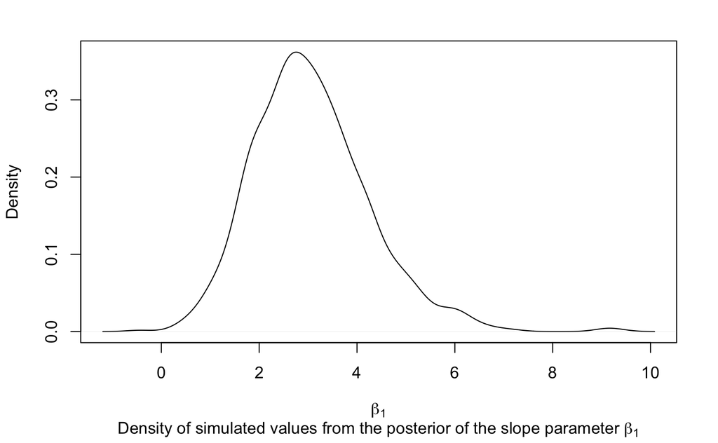

```r
library(latex2exp)
plot(density(s$y), xlab=TeX("$\\beta_{1}$"), main="", sub=TeX("Density of simulated values from the posterior of the slope parameter $\\beta_{1}$"))
```

In this setting, one parameter of interest is the LD-50, the value of the dose $x$ such that the probability of death is equal to one-half. It is straightforward to show that the LD-50 is equal to $\theta = -\beta_{0}/\beta_{1}$. One can obtain a simulated sample from the marginal posterior density of $\theta$ by computing a value of $\theta$ from each simulated pair $(\beta_{0}, \beta_{1})$.

Let’s plot its histogram.

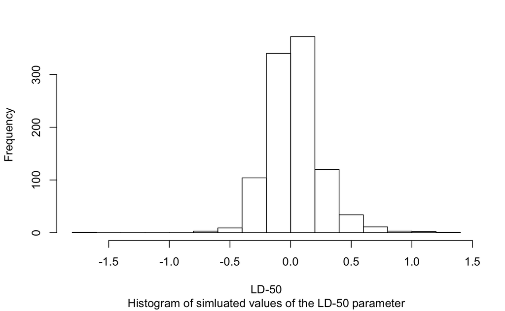

```r
theta = -s$x/s$y
hist(theta, xlab="LD-50", breaks=20, main="", sub="Histogram of simluated values of the LD-50 parameter")
```

In contrast to the histogram of $\beta_{1}$, the LD-50 is more difficult to estimate and the posterior density of this parameter is relatively wide.

We compute a 95% credible interval from the simulated draws of $\theta$.

```r
quantile(theta, c(0.025, 0.975))
```

```
      2.5%      97.5%
-0.3275681  0.5041901
```

The probability that $\theta$ is contained in the interval (-0.328, 0.504) is 0.95.

## Comparing two proportions

Howard (1998) considers the general problem of *comparing the proportions from two independent binomial distributions*. Suppose we observe $y_{1}$ distributed as $binomial(n_{1}, p_{1})$, and $y_{2}$ distributed as $binomial(n_{2}, p_{2})$. One wants to know if the data favor the hypothesis $\mathrm{H_{1}} : p_{1} > p_{2}$ or the hypothesis $\mathrm{H_{2}} : p_{1} < p_{2}$ and wants a measure of the strength of the evidence in support of one hypothesis. Howard gives a broad survey of frequentist and Bayesian approaches for comparing two proportions.

*From a Bayesian viewpoint, the important task is the construction of an appropriate prior distribution*. In Exercise 3, we explore the assumption that $p_{1}$ and $p_{2}$ are independent, where each proportion is assigned a beta prior. In this case, $p_{1}$ and $p_{2}$ have independent beta posterior distributions and it is straightforward to compute the probability of the hypotheses. However, *the assumption of independence of the proportions is questionable*, and we consider instead Howard’s “dependent prior” that he recommends for this particular testing problem.

Suppose that one is given the information that one proportion is equal to a particular value, say $p_{1} = 0.8$. This knowledge can influence a user’s prior beliefs about the location of the second proportion $p_{2}$. Specifically, if the user is given that $p_{1} = 0.8$, she may also believe that the value of $p_{2}$ is also close to 0.8. *This belief implies the use of dependent priors for $p_{1}$ and $p_{2}$*.

Howard’s special form of dependent prior is expressed as follows. First the proportions are transformed into the real-valued logit parameters

$$\theta_{1} = log\frac{p_{1}}{1 - p_{1}}, \ \theta_{2} = log\frac{p_{2}}{1 - p_{2}}.$$

Then suppose that given a value of $\theta_{1}$, the logit $\theta_{2}$ is assumed to be normally distributed with mean $\theta_{1}$ and standard deviation $\sigma$. By generalizing this idea, Howard proposes the dependent prior of the general form

$$g(p_{1},p_{2}) \propto e^{-(1/2)u^{2}}p_{1}^{\alpha-1}(1-p_{1})^{\beta-1}p_{2}^{\gamma-1}(1-p_{2})^{\delta-1}, \ 0<p_{1}, p_{2} < 1,$$

where $u = \frac{1}{\sigma}(\theta_{1}-\theta_{2}).$

This class of dependent priors is indexed by the parameters $(\alpha, \beta, \gamma, \delta, \sigma)$. The first four parameters reflect one’s beliefs about the locations of $p_{1}$ and $p_{2}$, and the parameter $\sigma$ indicates one’s prior belief in the dependence between the two proportions.

Suppose that $\alpha = \beta = \gamma = \delta = 1$, reflecting vague prior beliefs about each individual parameter. The logarithm of the dependent prior is defined in the R function howardprior(). Using the function mycontour() we plot contour plots of the dependent prior for values of the association parameter $\sigma$ = 2, 1, 0.5, and 0.25.

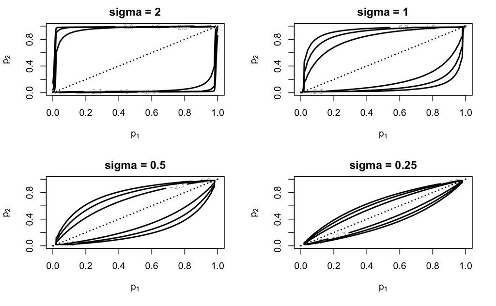

```r
library(latex2exp)
library(LearnBayes)
sigma = c(2,1,0.5,0.25)
plo = 0.0001
phi = 0.9999
par(mfrow=c(2,2))
for(i in 1:4){
  mycontour(howardprior, c(plo, phi, plo, phi), c(1, 1, 1, 1, sigma[i]), main=paste("sigma =", as.character(sigma[i])), xlab=TeX("$p_{1}$"), ylab=TeX("$p_{2}$"))
}
```

Note that as the value of $\sigma$ goes to zero, the prior is placing more of its mass along the line where the two proportions are equal.

Suppose we observe counts $y_{1}, y_{2}$ from the two binomial samples. The likelihood function is given by

$$L(p_{1}, p_{2}) \propto p_{1}^{y_{1}}(1-p_{1})^{n_{1}-y_{1}}p_{2}^{y_{2}}(1-p_{2})^{n_{2}-y_{2}}, \ 0 < p_{1},p_{2} < 1.$$

Combining the likelihood with the prior, one sees that the posterior density has the same functional “dependent” form with updated parameters

$$(\alpha + y_{1}, \beta + n_{1} - y_{1}, \gamma + y_{2}, \delta + n_{2} - y_{2}, \sigma).$$

We illustrate testing the hypotheses using a dataset discussed by Pearson (1947), shown in Table 4.3.

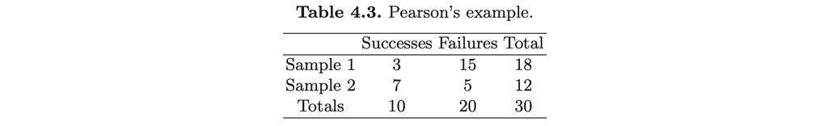

Since the posterior distribution is of the same functional form as the prior, we can use the same howardprior() function for the posterior calculations. Let’s plot contour plots of the posterior for the four values of the association parameter $\sigma$.

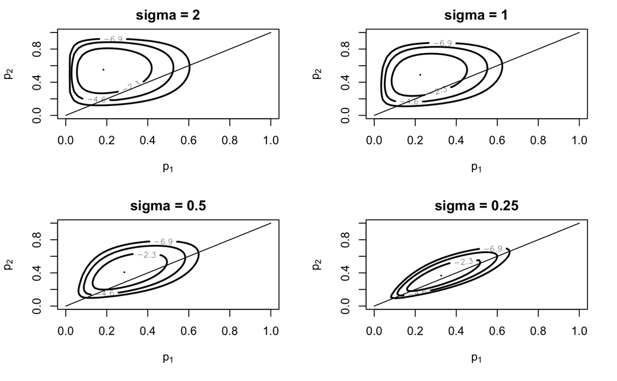

```r
library(latex2exp)
library(LearnBayes)

sigma = c(2, 1, 0.5, 0.25)
par(mfrow=c(2,2))
for(i in 1:4){
  mycontour(howardprior, c(plo, phi, plo, phi), c(1+3, 1+15, 1+7, 1+5, sigma[i]), main=paste("sigma =", as.character(sigma[i])), xlab=TeX("$p_{1}$"), ylab=TeX("$p_{2}$"))
  lines(c(0,1), c(0,1))
}
```

We can test the hypothesis $\mathrm{H_{1}}: p_{1} > p_{2}$ simply by computing the posterior probability of this region of the parameter space. We first produce, using the function simcontour(), a simulated sample from the posterior distribution of $(p_{1},p_{2})$, and then find the proportion of simulated pairs where $p_{1} > p_{2}$.

```r
for(sigma in c(2,1,0.5,0.25)){
  s = simcontour(howardprior, c(plo, phi, plo, phi), c(1+3, 1+15, 1+7, 1+5, sigma), 1000)
  cat(sprintf("(sigma = %.2f): P(p1>p2) = %.2f\n", sigma, sum(s$x > s$y)/1000))
}
```

```
(sigma = 2.00): P(p1>p2) = 0.02
(sigma = 1.00): P(p1>p2) = 0.03
(sigma = 0.50): P(p1>p2) = 0.11
(sigma = 0.25): P(p1>p2) = 0.25
```

We can see the posterior probability that $p_{1}$ exceeds $p_{2}$ for four choices of the dependent prior parameter $\sigma$. Note that *this posterior probability is sensitive to the prior belief about the dependence between the two proportions*.

## Summary of R functions

*howardprior()* – computes the logarithm of a dependent prior on two propor- tions proposed by Howard in a Statistical Science paper in 1998

*Usage*: howardprior(xy,par)

*Arguments*: xy, a matrix of parameter values where each row represents a value of the proportions (p1, p2); par, a vector containing parameter values alpha, beta, gamma, delta, sigma

*Value*: vector of values of the log posterior where each value corresponds to each row of the parameters in xy

*logisticpost()* – computes the log posterior density of (beta0, beta1) when yi are independent binomial(ni, pi) and logit(pi)=beta0+beta1*xi

*Usage*: logisticpost(beta,data)

*Arguments*: beta, a matrix of parameter values where each row represents a value of (beta0, beta1); data, a matrix of columns of covariate values x, sample sizes n, and number of successes y

*Value*: vector of values of the log posterior where each value corresponds to each row of the parameters in beta

*mycontour()* – for a general two parameter density, draws a contour graph where the contour lines are drawn at 10%, 1%, and .1% of the height at the mode

*Usage*: mycontour(logf,limits,data,…)

*Arguments*: logf, a function that defines the logarithm of the density; limits, a vector of limits (xlo, xhi, ylo, yhi) where the graph is to be drawn; data, a vector or list of parameters associated with the function logpost; …, further arguments to pass to contour

*Value*: a contour graph of the density is drawn

*normchi2post()* – computes the log of the posterior density of a mean M and a variance S2 when a sample is taken from a normal density and a standard noninformative prior is used

*Usage*: normchi2post(theta,data)

*Arguments*: theta, a matrix of parameter values where each row is a value of (M, S2); data, a vector containing the sample observations

*Value*: a vector of values of the log posterior where the values correspond to the rows in theta

*normpostsim()* – gives a simulated sample from the joint posterior distribution of the mean and variance for a normal sampling prior with a noninformative prior

*Usage*: normpostsim(data,m)

*Arguments*: data, a vector containing the sample observations; m, number of simulations desired

*Value*: mu, vector of simulated draws of normal mean; sigma2, vector of sim- ulated draws of normal variance

*rdirichlet()* – simulates values from a Dirichlet distribution

*Usage*: rdirichlet(n,par)

*Arguments*: n, the number of simulations required; par, the vector of param- eters of the Dirichlet distribution

*Value*: a matrix of simulated draws, where a row contains one simulated Dirich- let draw

*simcontour()* – for a general two-parameter density defined on a grid, simulates a random sample

*Usage*: simcontour(logf,limits,data,m)

*Arguments*: logf, a function that defines the logarithm of the density; limits, a vector of limits (xlo, xhi, ylo, yhi) that cover the joint probability density; data, a vector or list of parameters associated with the function logpost; m, the size of the simulated sample

*Value*: x, the vector of simulated draws of the first parameter; y, the vector of simulated draws of the second parameter